# Session 5: Generative network models

Compared to what? Random graphs as baselines

Published

October 4, 2026

## Goals

- understand that a network statistic means little without a **baseline**,
- simulate networks from the classic generative models: random graphs, the configuration model, small worlds, preferential attachment,
- compare an observed network to simulated ones,
- see which simple mechanisms produce which structures.

```r
library(tidyverse)
library(igraph)
set.seed(2027)
```

## 1. The question: is this a lot?

```r
g <- make_graph("Zachary")
transitivity(g)
```

```
[1] 0.2556818
```

**NoteThink first**

Is a transitivity of about 0.26 high or low? You cannot answer without asking: *compared to what?*

## 2. The random graph (Erdős–Rényi)

The simplest baseline keeps the number of nodes and edges, and places edges completely at random.

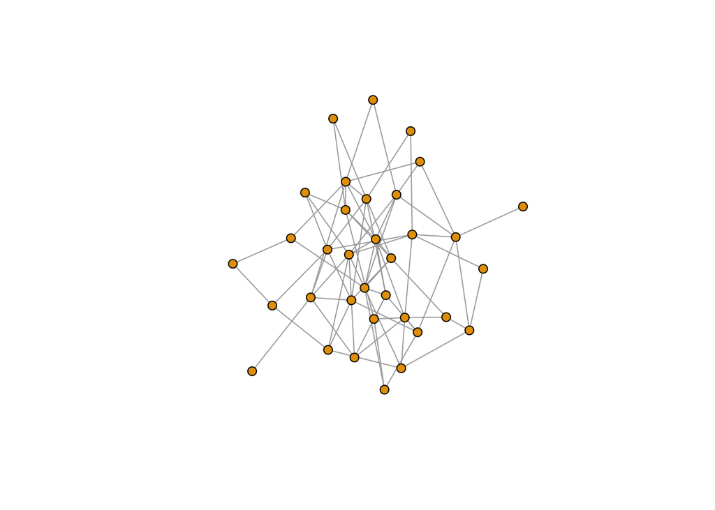

```r
n <- vcount(g)
m <- ecount(g)

g_random <- sample_gnm(n, m)
plot(g_random, vertex.size = 6, vertex.label = NA)
```

```r
transitivity(g_random)
```

```
[1] 0.1256983
```

One draw is not enough. Simulate many:

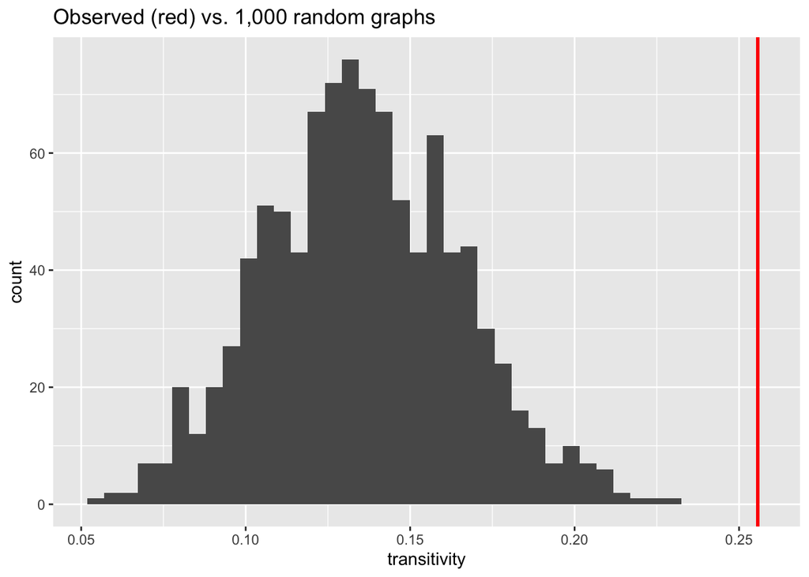

```r
sim_er <- replicate(1000, transitivity(sample_gnm(n, m)))

tibble(transitivity = sim_er) |>
  ggplot(aes(transitivity)) +
  geom_histogram(bins = 40) +
  geom_vline(xintercept = transitivity(g), colour = "red", linewidth = 1) +
  labs(title = "Observed (red) vs. 1,000 random graphs")
```

## 3. Holding degree fixed: the configuration model

Maybe clustering is only high because some nodes have many ties. The configuration model keeps **each node’s degree** and randomises everything else.

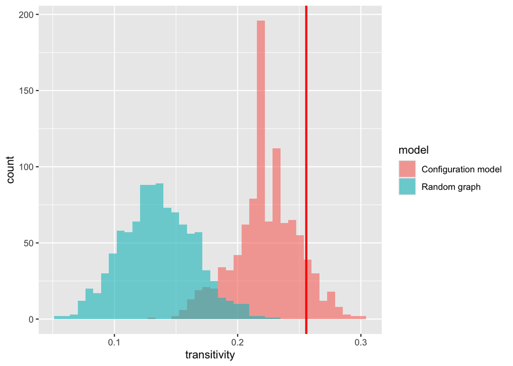

```r
sim_conf <- replicate(1000, transitivity(sample_degseq(degree(g), method = "vl")))

tibble(
  model = rep(c("Random graph", "Configuration model"), each = 1000),
  transitivity = c(sim_er, sim_conf)
) |>
  ggplot(aes(transitivity, fill = model)) +
  geom_histogram(bins = 40, alpha = 0.6, position = "identity") +
  geom_vline(xintercept = transitivity(g), colour = "red", linewidth = 1)
```

**WarningDiscuss**

If the observed value lies outside the configuration-model distribution, clustering is not just a by-product of the degree distribution. What social or political mechanism could produce it?

## 4. Mechanisms that generate structure

**Small world** (Watts–Strogatz): a regular lattice with a few random shortcuts gives high clustering *and* short paths.

```r
g_sw <- sample_smallworld(dim = 1, size = 100, nei = 3, p = 0.05)
c(clustering = transitivity(g_sw), avg_path = mean_distance(g_sw))
```

```
clustering   avg_path
 0.4431373  3.6400000
```

**Preferential attachment** (Barabási–Albert): new nodes prefer to tie to already well-connected nodes (“the rich get richer”).

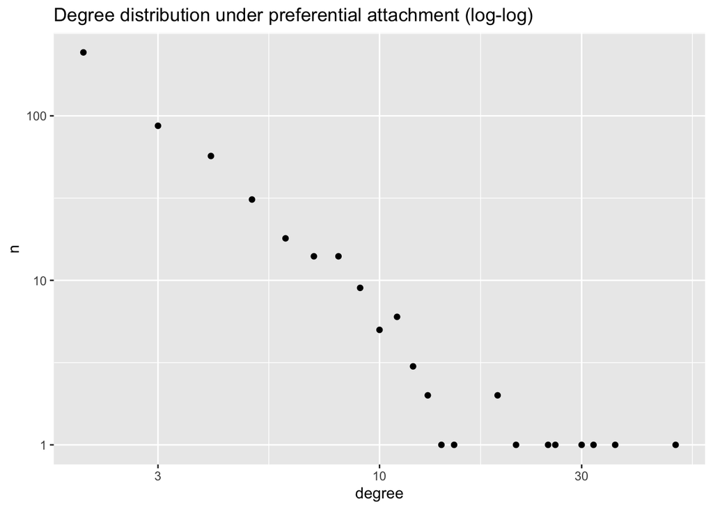

```r
g_pa <- sample_pa(500, m = 2, directed = FALSE)

tibble(degree = degree(g_pa)) |>
  count(degree) |>
  ggplot(aes(degree, n)) +
  geom_point() +
  scale_x_log10() + scale_y_log10() +
  labs(title = "Degree distribution under preferential attachment (log-log)")
```

**NoteThink first**

Which IR networks might grow by preferential attachment? Think of new states joining organisations, or new trade partners.

## Your turn

**TipExercise**

1. Repeat the comparison in Sections 2–3 for **average path length** instead of transitivity.
2. Apply both baselines to the network from Session 4 (or your own IR network). Which features are “surprising”?
3. Vary `p` in the small-world model from 0 to 1 and plot clustering and average path length against `p`.

```r
# your code here
```